# A smooth Introduction to Portfolio Management

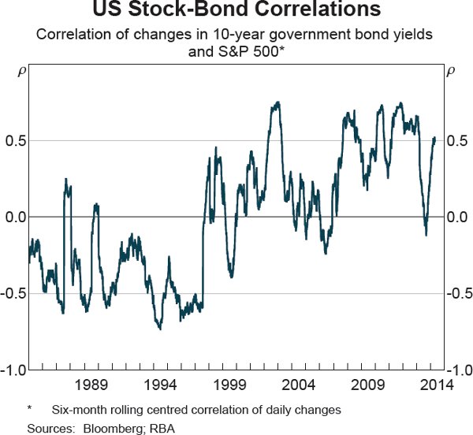

In this short blog I am going to introduce the basics of portfolio theory. It is an introduction to a set of blogs dedicated to portfolio choices that focus on long holding periods. In particular, these periods are between 10 and 30 years. Several studies revealed that frequently switching between funds leads investors to withdraw from and invest into the market at wrong times. This implies that market-timing does not work for the average investor. Dalbar for instance, publishes continuous reports on [“Quantitative Analysis of Investor Behavior”](https://www.qidllc.com/wp-content/uploads/2016/02/2016-Dalbar-QAIB-Report.pdf) that support the idea that short-term investing might lead to make the exact wrong decision. The definitions below will help to build methodologies for a systematic approach to investing. I will try to keep everything as short as possible.  
So lets start with the **risk-return tradeoff**, which is the principle that expected return rises with an increase in risk. Thus, an investor can expect higher profits only if the investor is willing to accept the possibility of higher losses. Markowitz (1991) shows how to maximize expected return for a given level of variance. He assumes that investors prefer asset A over B with same expected return, whenever asset A has a smaller variance than asset B.

### Definitions

In order to get a logical understanding of the topic and developing it further, we need to make some definitions that will be referred to across posts. First and foremost, the **portfolio return** is defined as:
$$r_p = \sum_{i=1}^n w_i r_i = w'r$$
with **weights** summing up to 1:
$$\sum_{i=1}^n w_i = w' 1$$

The **expected return of a portfolio** is
$$\mu_p = \mathop {\mathbb E}[r_p] = \sum_{i=1}^n w_i \mathop {\mathbb E}[r_i] = w' \mathop {\mathbb E}[r]$$
and the corresponding **variance of the portfolio return** is:
$$\sigma_p^2 = \sum_{i=1}^n w_i^2 \sigma_i^2 + \sum_{i=1}^n\sum_{i\neq j} w_i w_j Cov[r_i, r_j] = w'\Sigma w$$

### Diversification

The last equation reveals that portfolio risk consists of two components. The first part is called idiosyncratic risk and is almost fully diversifiable. In general, diversification is a technique that reduces risk by allocating investments among various financial instruments, industries, and other categories. It aims to maximize return by investing in different areas or assets that are expected to move in different directions given a specific shock. As a result, **idiosyncratic risks**, that are risks specific to a company, industry, market, economy, or country are reduced, if not **eliminated**. The concept of diversification can also be shown by a mathematical proof, which is just a simple one-liner. For this purpose we assume a zero covariance, meaning that the correlation between assets is zero. If we use an equally weighted portfolio, such that $w_i = 1/n$, then the portfolio’s variance will converge to zero as n goes to infinity. Most ETFs on indices however are value-weighted and automatically introduce exposure to a value risk premium, which might not be intended by the investor. In particular, the proof below would also hold for a value-weighted portfolios as the weights would be a function of individual market capitalization and $n$, such that $(w_i = MC_i/(\overline{MC}\cdot n)$. Thus the portfolio variance converges slower to 0 as $n$ grows linearly instead of exponentially.

#### Proof:

$$\lim_{n \to \infty} \sigma_p^2 = \lim_{n \rightarrow \infty} \sum_{i=1}^n \frac{ \sigma_i^2} {n^2} + \sum_{i=1}^n\sum_{i\neq j} \frac{ 0} {n^2}= 0$$
We can see that it is desirable to benefit from the **diversification effect** which reduces portfolio risk.
However, the second part of the portfolio variance is the weighted covariance. This part can also be represented by entries of the correlation matrix multiplied by the standard deviation. Hence, any correlation contributes positively or negatively to the overall portfolio risk. For illustration purposes consider the plot below: It shows two assets with various return correlations. The blue dots indicate a full investment in either one of the two assets. Further, the dashed line indicates all possible portfolios constructed by these two assets. Only if the correlation is perfectly negative, the portfolio risk will be zero.

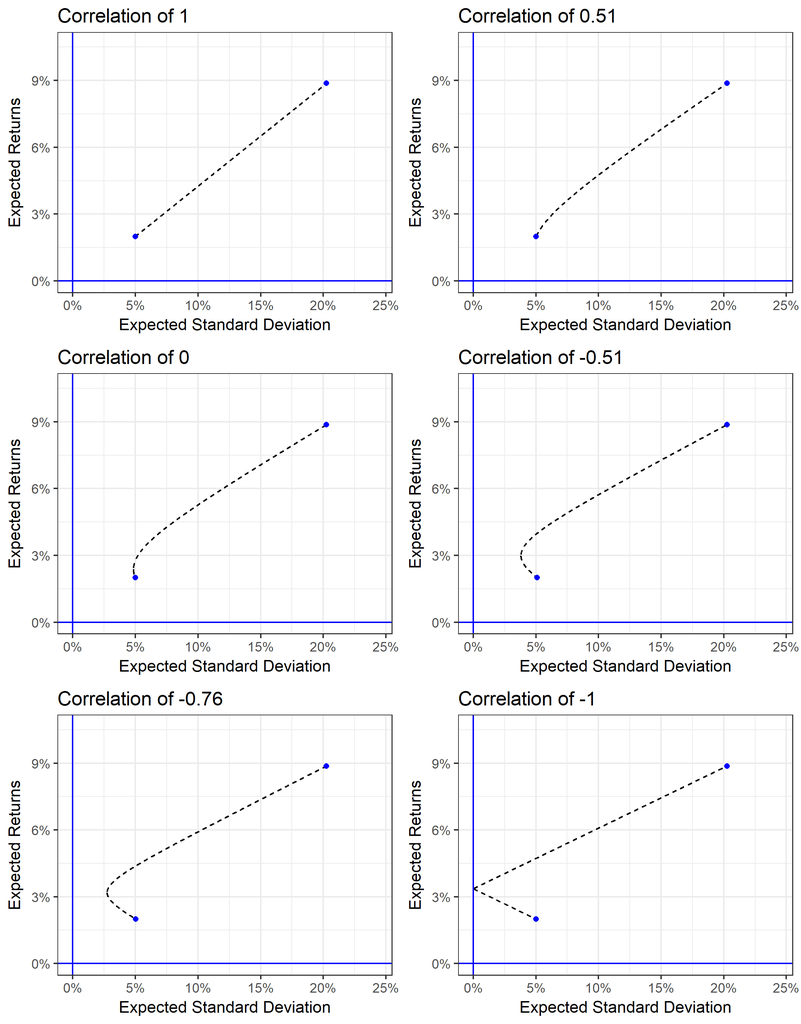

Unfortunately, zero correlations across assets are unobservable (see also US Stock-Bond plot) and thus, the second part of the portfolio variance is unequal to zero. In general, **systematic risks** are variations in inflation rates and exchange rates, political and economic instability, war, and interest rate changes, which is **undiversifiable**. Nonetheless, the latter risk component is supposed to be priced in financial markets and is the compensation for bearing systematic risks. This compensation is known as the **risk premium** or discount rate. These discount rates are time varying as a result of time variation in the underlying portfolio return correlations. Idiosyncratic risk on the other hand, is not compensated as it is diversifiable. Obviously, if the last part is negative, the entire variation is smaller, which is the main idea of the 60/40 asset allocation rule that invests in stocks and bonds. The idea thereby is that the two asset classes generally move in opposite directions and are thus negatively correlated. Unfortunately, since 1999, the negative relationship has turned positive for long-term holdings as plotted above.

Fortunately, a very large set of different approaches exists that try to implement low correlations with the market and simultaneously take advantage of the diversification effect. Some of these methodologies are discussed in later posts. These examples try to optimize the trade-off between risk and return, but also wrt higher moments. Some of these methods also consider reduced transaction costs by decreasing the turnover or the number of assets $n$ as there exists an obvious trade-off between high diversification, implying a large number of assets $n$, and fees.

Markowitz, Harry M. 1991. “Foundations of Portfolio Theory.” *The Journal of Finance* 46 (2). Wiley Online Library: 469–77.